# **Serie Temporal de la Temperatura de Bogota segun datos de la estacion Puente Aranda**

Diego Alexander Torres

Mayo de 2020

## Estudio climatico

### 1.Introduccion

En el mundo es muy conocido que la temperatura es una de las magnitudes que mas se utilizan con el fin de poder describir y explicar el estado de la atmosfera y explicar el estado meteorologico. La temperatura va cambiando a lo largo del dia, varía en dias nublados, o con viento, en la noche, de una estacion a otra, en distintos lugares, etc. Nunca vamos a tener una temperatura igual y estable durante muchas horas, por lo que es necesario medirla desde diferentes puntos y de manera constante para así poder obtener conclusiones con fines ambientales. La temperatura es, sin duda alguna, la variable mas estudiada cuando se habla de calientamiento global, sin embargo, las conclusiones sobre este fenomeno climatico no se obtienen solamente de medir la temperatura, sino tambien las causas que generan estas variaciones. Entre los diversos factores que afectan el comportamiento de la temperatura encontramos los contaminantes atmosfericos: los denominados aerosoles (PM) o demas gases y particulas son muestras de algunos de ellos.

Bogota sera la ciudad escogida para llevar a cabo un estudio estadistico del comportamiento de la temperatura a partir de su relacion con diferentes contaminantes atmosfericos. El objetivo principal de este proyecto es el de poder pronosticar la temperatura promedio mensual de la ciudad de Bogota por los proximos años a partir de los datos de la estacion Puente Aranda, y de su relacion con algunos contaminantes. Para lograr lo anterior, uno de los recursos utilizados es el ajuste de modelos de series temporales, los cuales pueden ser tanto univariados como multivariados, por lo que optaremos por realizar ambos: uno de la temperatura solamente, y otro con los demas contaminantes. Finalmente, se compararan los resultados obtenidos de los modelos.

### 2. Analisis descriptivo

Antes de dar inicio, se presentaran las librerias utilizadas:

```r
library(dplyr)
library(lubridate)
library(ggplot2)
library(ggpubr)
library(corrplot)
library(tseries)
library(ggfortify)
library(TSA)
library(MTS)
library(mvtnorm)
library(forecast)
```

Ahora bien, realizaremos un analisis descriptivo de la informacion a utilizar. Iniciaremos con el encabezado de los datos

| DateTime | Temperature | PM10 | OZONO | NO2 |
| --- | --- | --- | --- | --- |
| 2009-01-01 | 14.27 | 59.15 | 10.71 | 14.25 |
| 2009-02-01 | 14.39 | 65.05 | 16.79 | 18.84 |
| 2009-03-01 | 14.42 | 69.30 | 15.85 | 15.34 |
| 2009-04-01 | 14.90 | 55.03 | 20.26 | 11.97 |
| 2009-05-01 | 14.90 | 56.52 | 13.07 | 11.38 |
| 2009-06-01 | 14.54 | 53.72 | 11.82 | 7.72 |
| 2009-07-01 | 14.13 | 46.16 | 10.66 | 8.82 |

Ahora, presentaremos una tabla con informacion descriptiva mas detallada de la distribucion mensual de los datos de cada una de las variables utilizadas en este proyecto.

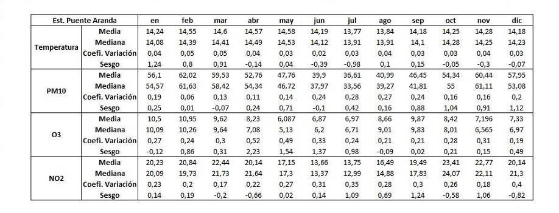

Y finalmente un boxplot que resume el comportamiento mensual de cada variable.

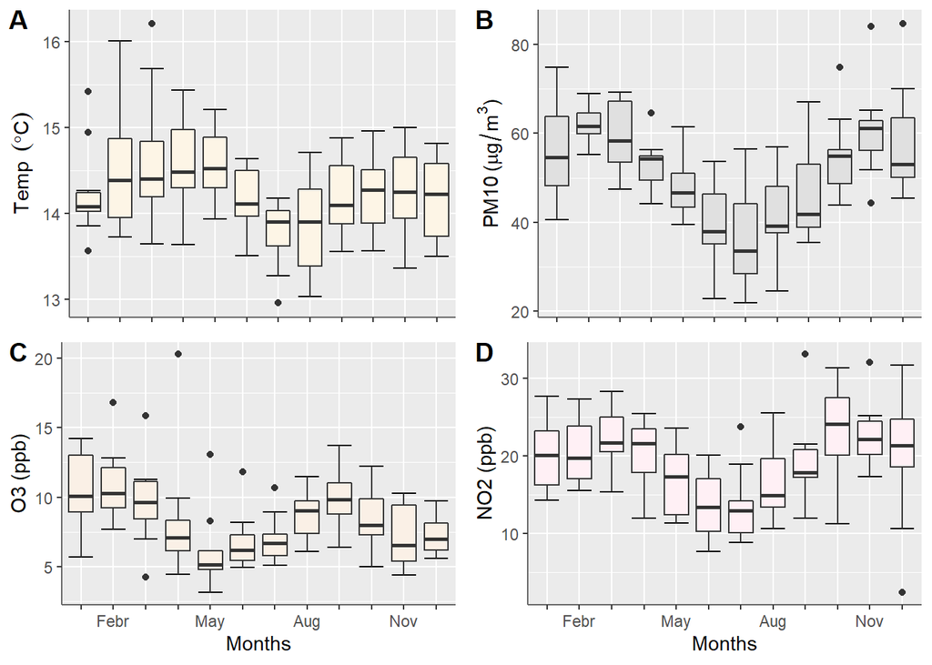

La base de datos trabajada se logra a partir de la transformacion de los datos horarios a mensuales, mediante el promedio del total de registros por cada mes. De esta manera, es posible visualizar mejor el comportamiento que suele tener cada variable durante el año. al observar los boxplot obtenidos, se observa que existe una relacion cercana y positiva entre dos de los tres contaminantes (NO2 y PM10) y la temperatura, mostrando un comportamiento oscilatorio dependiendo de la epoca del año, teniendo picos en los meses de marzo y noviembre. Mientras que con el ozono ocurre una oscilacion desfasada, posiblemente a una relacion inversa entre estos.

### 3. Analisis series temporales

#### 3.1 Analisis univariado

Una vez descrita la variable Temperatura, procederemos a generar la serie temporal que se usara para realizar el pronostico univariado. Se realizara mediante la funcion `ts`.

```r
Te <- ts(pte_Aranda$Temperature, start = c(2009, 1), frequency = 12)
print(head(Te, 36))
```

```
##        Jan   Feb   Mar   Apr   May   Jun   Jul   Aug   Sep   Oct   Nov
## 2009 14.27 14.39 14.42 14.90 14.90 14.54 14.13 14.55 14.63 14.53 14.87
## 2010 14.95 15.82 15.69 15.21 15.11 14.47 14.03 13.94 14.10 14.28 13.68
## 2011 13.86 13.92 13.65 14.19 14.45 14.54 13.76 13.91 13.84 13.57 13.77
##        Dec
## 2009 14.79
## 2010 13.50
## 2011 14.23
```

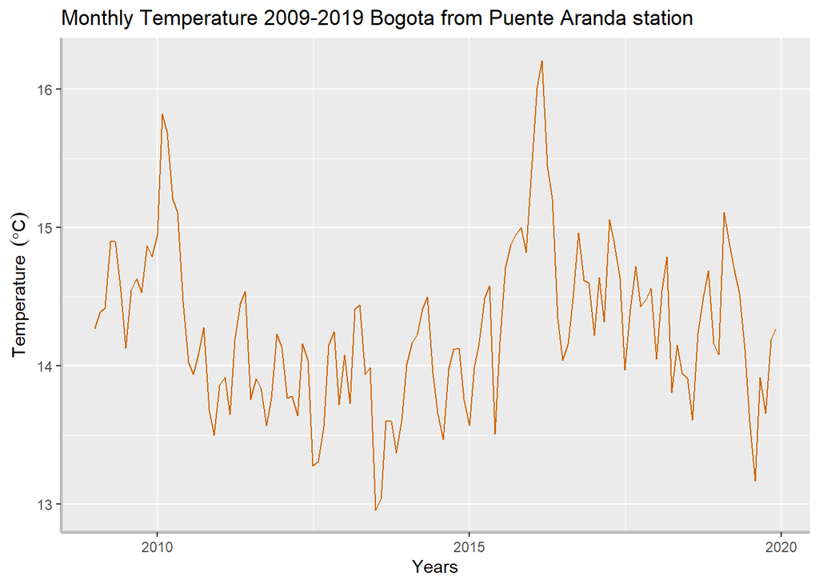

```r
ggplot(pte_Aranda, aes(x = DateTime, y = Temperature)) +
  geom_line(color = "darkorange3") +
  theme(axis.line = element_line(colour = "grey",
                      size = 1, linetype = "solid")) +
  ylab(parse(text = "Temperature ~~ group('(', degree * C, ')')")) +
  xlab("Years") +
  ggtitle("Monthly Temperature 2009-2019 Bogota from Puente Aranda station")
```

Segun la serie obtenida, tenemos la presencia de una periodicidad no estacional repetida cada cinco años. Ademas, la serie tiene una tendencia oscilatoria que parece moverse al rededor de los 14,3 grados centrigrados aproximadamente, lo que podria indicar ausencia de tendencia. Sin embargo, veremos sus componentes por separado mediante la funcion `autoplot`.

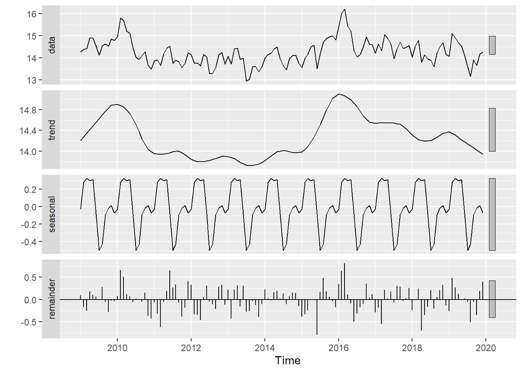

```r
autoplot(stl(Te, s.window = 'periodic'))
```

Mirando los componentes por separado se confirma un ciclo muy marcado de cinco años de manera oscilatoria y de la presencia de estaciones lo que podria traducirse en que la serie no seria estacionaria.

Antes de comenzar con cualquier pronostico, es importante asegurarnos de si la serie es estacionaria en media o no, y de si de requiere de alguna transformacion lineal de sus datos. En ese orden de ideas, mediante una prueba de Dickey-Fuller podremos estar seguros de si nuestra serie ya es estacionaria o no. El test tiene las siguientes hipotesis:

H0: la serie no es estacionaria.  
H1: la serie es estacionaria.

```r
adf.test(Te)
```

```
##
##  Augmented Dickey-Fuller Test
##
## data:  Te
## Dickey-Fuller = -2.8245, Lag order = 5, p-value = 0.2336
## alternative hypothesis: stationary
```

De esta manera, se comprueba que la serie efectivamente no es estacionaria. Para lograr la estacionariedad en media, se generara la diferenciacion de la serie; y segun un analisis de Box-Cox, observaremos si requerimos de alguna suavizacion de los datos para reducir la varianza a un valor constante.  
iniciaremos con la funcion de Box-Cox:

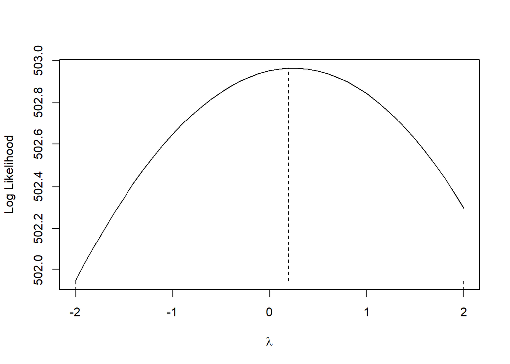

```r
BoxCox.ar(Te)
```

Ahora, procederemos a lograr la estacionariedad en la variable temperatura asi:

```r
#Te <- ts(diff(log(pte_Aranda$Temperature), 2), start = c(2009, 1), frequency = 12)
#fit <- auto.arima(Te)

#print(tail(Te, 35))

#adf.test(Te)

#autoplot(Te) +
  #geom_line(color = "darkorange3") +
  #theme(axis.line = element_line(colour = "grey",
   #                   size = 1, linetype = "solid")) +
  #ylab(parse(text = "diff(log(Temp))")) +
  #xlab("Years") +
  #ggtitle("differenciate log(temperature)")
```

Una vez obtenida la serie de la transformacion, procederemos a generar un modelo ARIMA que nos permita pronostica a partir de la serie temporal generada, el autocorrelograma es una herramienta que nos permitira obtener pistas sobre los parametros que podria tomar el modelo, aunque tambien podemos visualizar el autocorrelograma parcial.

```r
#par(mfrow=c(1,2))

#acf(Te, main = parse(text = "Transf-Temperatura"), col="gray47", lag.max = 15)
#pacf(Te, main = parse(text = "Transf-Temperatura"), col="gray47", lag.max = 15)
```

Sin embargo, haremos uso de la funcion `auto.arima` para estar seguros sobre el modelo que podria ajustarse.

```r
Te <- ts(diff(log(pte_Aranda$Temperature), differences = 2), start = c(2009, 1), frequency = 12)
fit <- auto.arima(Te)
fit
```

```
## Series: Te
## ARIMA(5,0,0)(2,0,0)[12] with zero mean
##
## Coefficients:
##           ar1      ar2      ar3      ar4      ar5    sar1    sar2
##       -0.9683  -0.8757  -0.6934  -0.4976  -0.2616  0.1408  0.3193
## s.e.   0.0888   0.1147   0.1226   0.1138   0.0857  0.0850  0.0944
##
## sigma^2 estimated as 0.0009047:  log likelihood=272.33
## AIC=-528.66   AICc=-527.47   BIC=-505.72
```

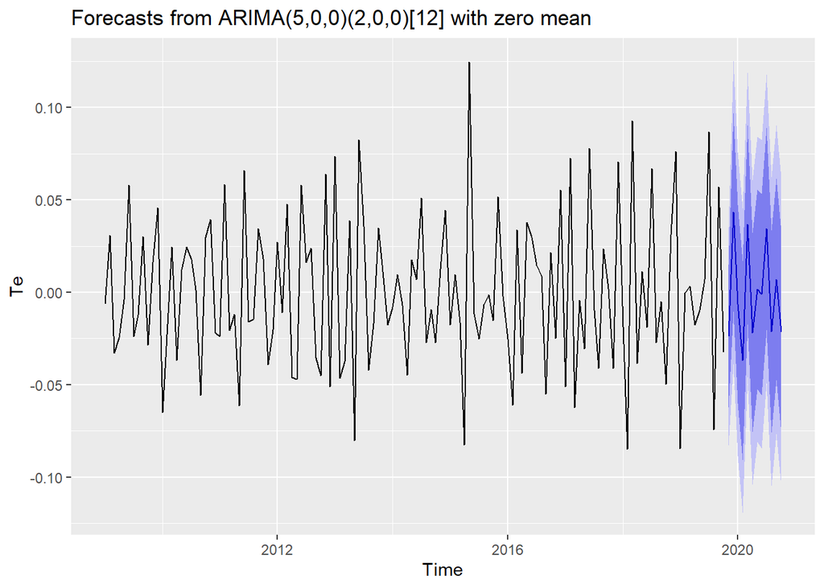

```r
autoplot(forecast(fit, h = 12))
```

```r
Te1 <- ts(log(pte_Aranda$Temperature), start = c(2009, 1), frequency = 12)
fit <- auto.arima(Te1)
fit
```

```
## Series: Te1
## ARIMA(1,0,0)(2,0,0)[12] with non-zero mean
##
## Coefficients:
##          ar1    sar1    sar2    mean
##       0.7542  0.1524  0.2255  2.6584
## s.e.  0.0566  0.0849  0.0937  0.0132
##
## sigma^2 estimated as 0.0006736:  log likelihood=295.43
## AIC=-580.85   AICc=-580.38   BIC=-566.44
```

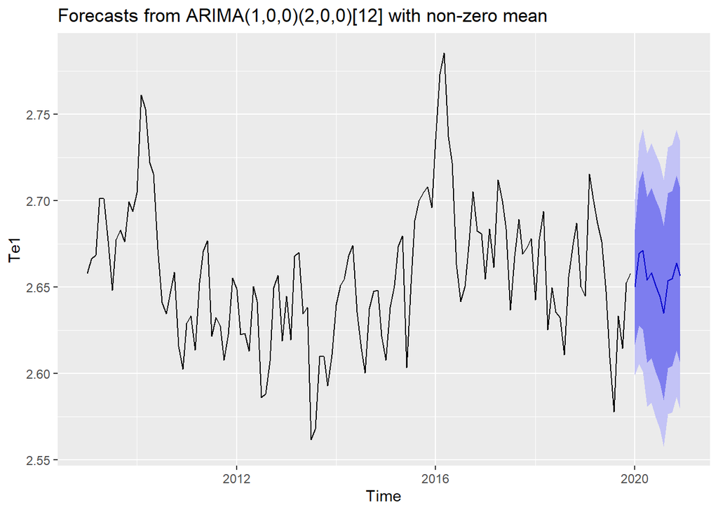

```r
autoplot(forecast(fit, h = 12))
```

```r
Te2 <- ts(diff(log(pte_Aranda$Temperature), 4), start = c(2009, 1), frequency = 12)
fit <- auto.arima(Te2)
fit
```

```
## Series: Te2
## ARIMA(1,0,0)(2,0,0)[12] with zero mean
##
## Coefficients:
##          ar1    sar1    sar2
##       0.5781  0.1841  0.2711
## s.e.  0.0728  0.0861  0.0932
##
## sigma^2 estimated as 0.001273:  log likelihood=245.03
## AIC=-482.06   AICc=-481.74   BIC=-470.65
```

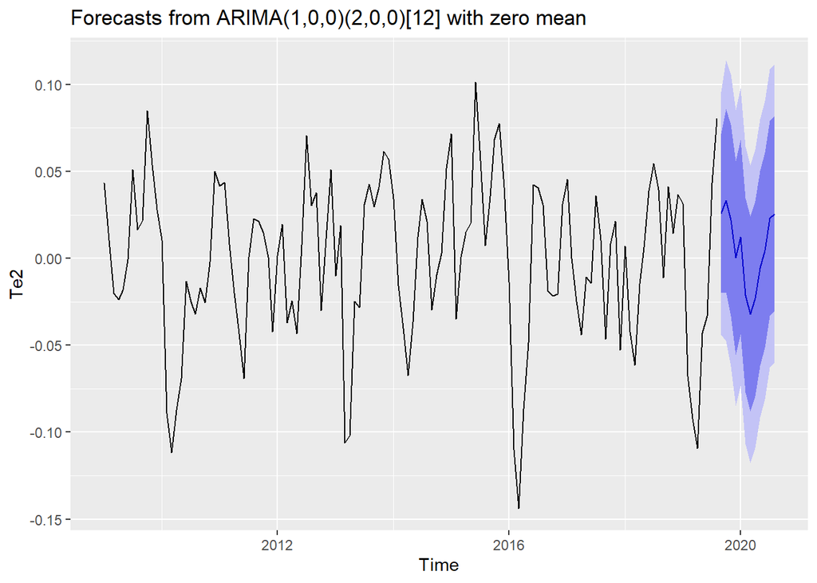

```r
autoplot(forecast(fit, h = 12))
```

```r
Te3 <- ts(diff(log(pte_Aranda$Temperature), 6), start = c(2009, 1), frequency = 12)
fit <- auto.arima(Te3)
fit
```

```
## Series: Te3
## ARIMA(2,0,2) with zero mean
##
## Coefficients:
##          ar1      ar2      ma1     ma2
##       1.6600  -0.8522  -1.1432  0.4538
## s.e.  0.0766   0.0707   0.1292  0.2447
##
## sigma^2 estimated as 0.001198:  log likelihood=246.46
## AIC=-482.92   AICc=-482.42   BIC=-468.74
```

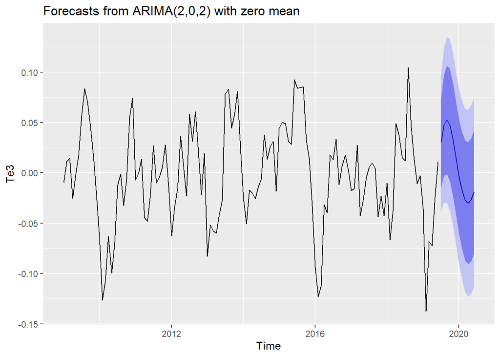

```r
autoplot(forecast(fit, h = 12))
```

```r
Te4 <- ts(diff(log(pte_Aranda$Temperature), 8), start = c(2009, 1), frequency = 12)
fit <- auto.arima(Te4)
fit
```

```
## Series: Te4
## ARIMA(1,0,0)(2,0,0)[12] with zero mean
##
## Coefficients:
##          ar1    sar1    sar2
##       0.7070  0.1648  0.2490
## s.e.  0.0629  0.0892  0.0951
##
## sigma^2 estimated as 0.001437:  log likelihood=229.94
## AIC=-451.89   AICc=-451.55   BIC=-440.61
```

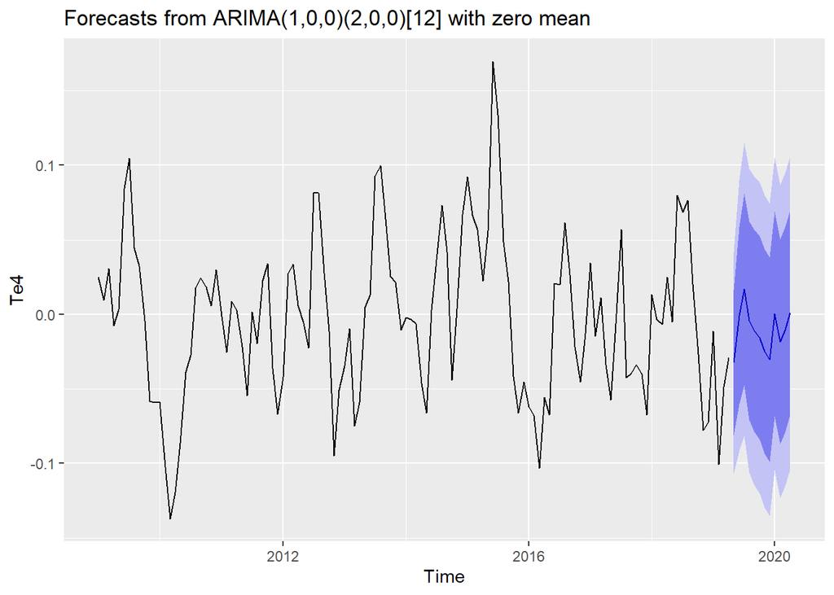

```r
autoplot(forecast(fit, h = 12))
```

```r
#autoplot(forecast(fit, h = 12))
#autoplot(forecast(fit1, h = 12))
```

```r
#pte_Aranda_HW <- HoltWinters(Te)
#forecast <- predict(pte_Aranda_HW, n.ahead = 12, prediction.interval = T, level = 0.95)
#plot(pte_Aranda_HW, forecast)
```

#### 3.2 Analisis multivariado

Para esta seccion completa, es fundamental presentar series de tiempo completas, es decir, sin datos ausentes. Con anterioridad se realizo el analisis del porcentaje de datos completos que cada variable tenia y los resultados fueron los siguientes:

| Temperature | PM10 | OZONO | NO2 |
| --- | --- | --- | --- |
| 100 | 100 | 95.45 | 84.85 |

De la tabla se observa que hay dos contaminantes que no tienen registros completos, lo que dificulta la eficacia del analisis de la serie multivariada debido al subregistro. Lo que podemos hacer es llenar estos datos faltantes con la media o la mediana por mes, dependiendo del comportamiento de sus outliers. Remitiendonos nuevamente a la figura con los boxplot, se observa que los outliers son significativos, por lo que seria util utilizar la mediana como metodo de relleno.

Una vez completos los datos, procedemos a observar la relacion entre las variables mediante un grafico de correlacion.

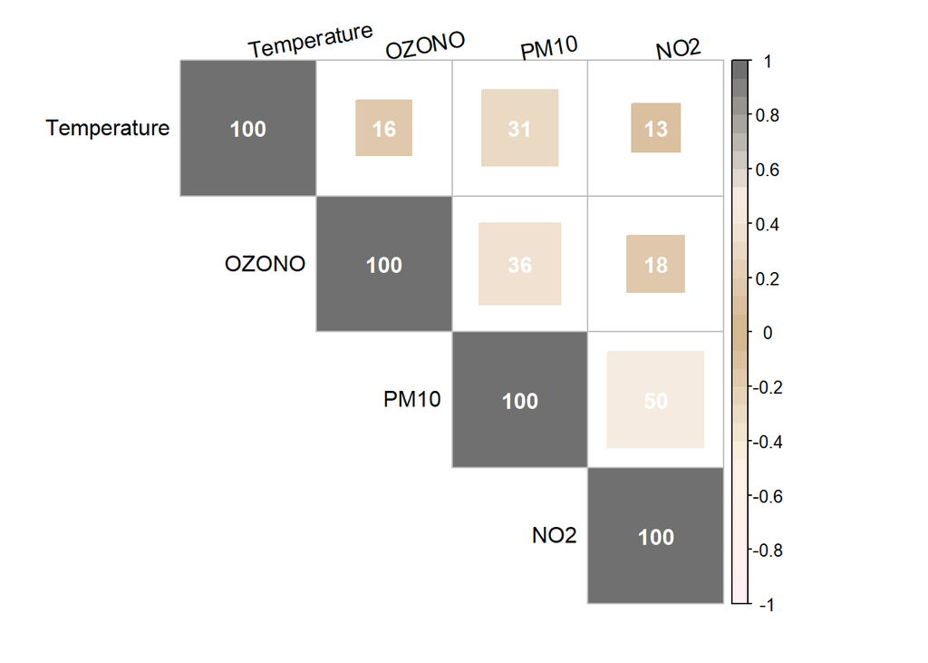

```r
#rampa de color generada
pal <- colorRampPalette(c( "lavenderblush", "oldlace","tan", "linen","gray44"))

corrplot(cor(pte_Aranda_F[,2:5]), method = "square", type = "upper", order = "hclust",
         tl.col = "black", tl.srt = 010, is.corr = T, addCoef.col = F, col = pal(30),
         addCoefasPercent = T)
```

Del grafico de correlacion podemos observar que la correlacion lineal de la temperatura con los tres contaminantes es relativamente baja, por lo que estas variables tienen un tipo de relacion distinta a lineal. Ademas, observamos una relacion de linearidad algo fuerte entre las particulas menores a 10 micras (PM10) y el NO$_2$ quizas debido a su origen antropogenico comun

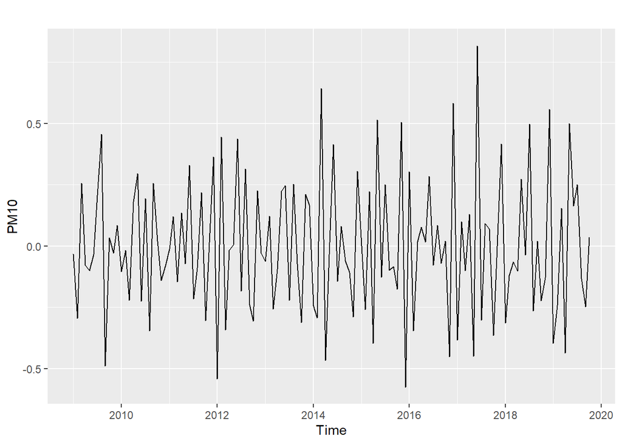

```r
PM10 <- ts(diff(log(pte_Aranda_F$PM10), differences = 2), start = c(2009, 1), frequency = 12)
autoplot(PM10)
```

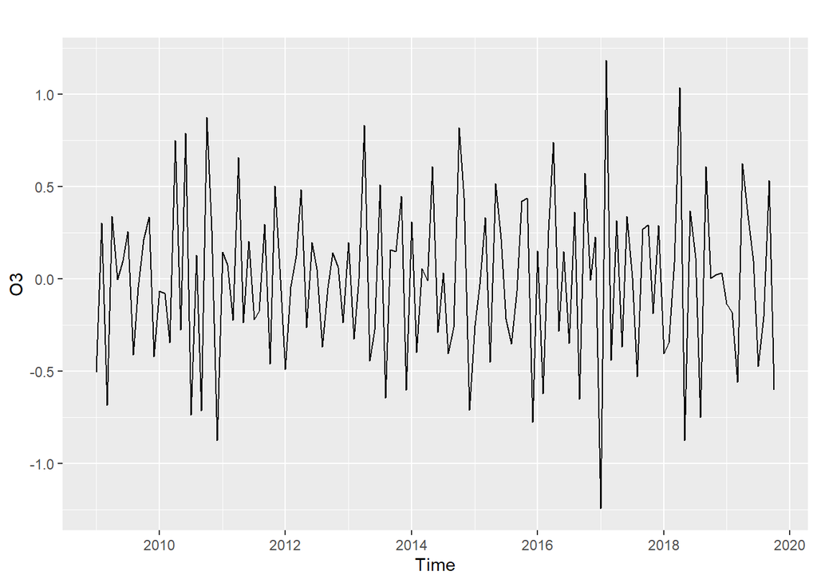

```r
O3 <- ts(diff(log(pte_Aranda_F$OZONO), differences = 2), start = c(2009, 1), frequency = 12)
autoplot(O3)
```

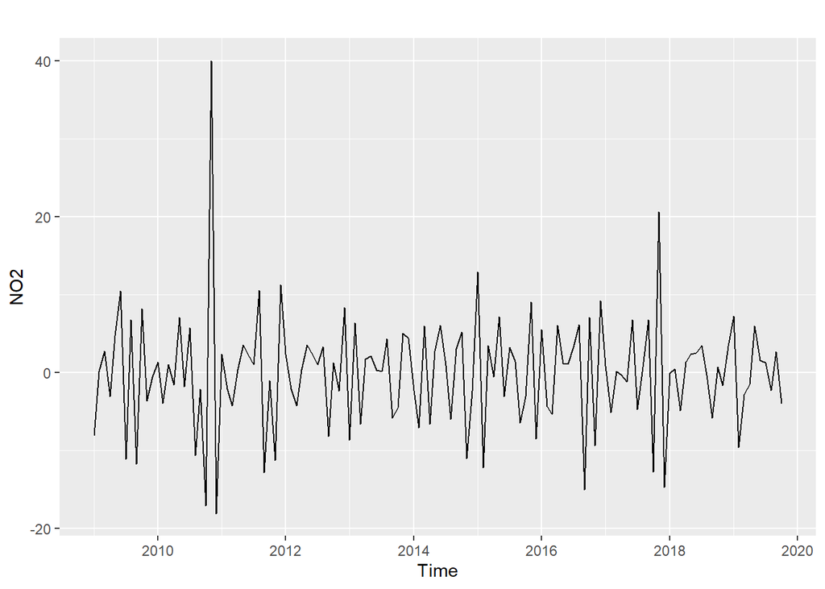

```r
NO2 <- ts(diff(pte_Aranda_F$NO2, differences = 2), start = c(2009, 1), frequency = 12)
autoplot(NO2)
```

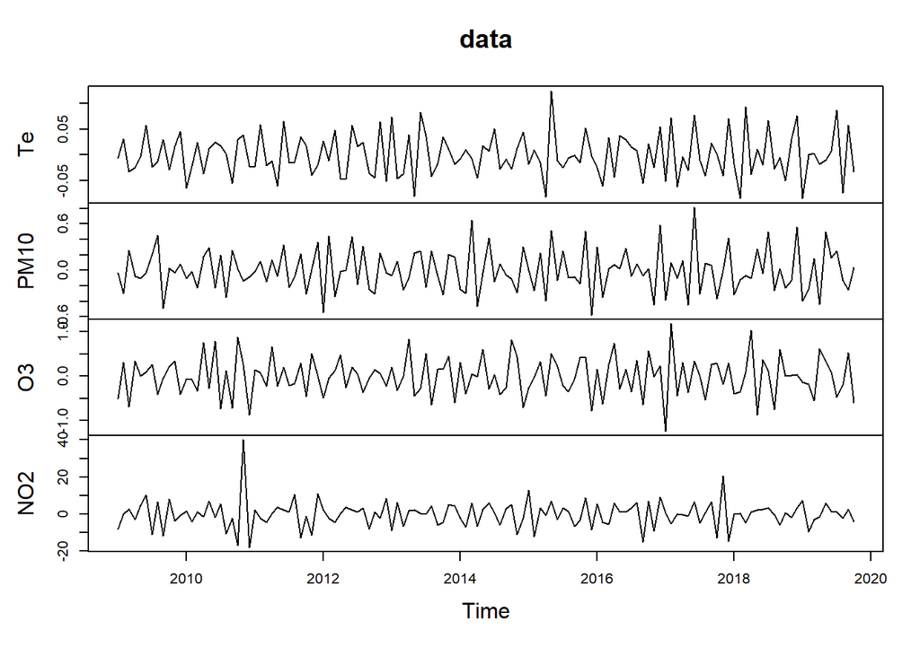

```r
multi <- cbind(Te, PM10, O3, NO2)
MTSplot(multi)
```

```r
var <- VARorder(multi)
```

```
## selected order: aic =  13
## selected order: bic =  2
## selected order: hq =  6
## Summary table:
##        p      AIC     BIC      HQ     M(p) p-value
##  [1,]  0  -6.7945 -6.7945 -6.7945   0.0000  0.0000
##  [2,]  1  -7.8683 -7.5154 -7.7249 147.1762  0.0000
##  [3,]  2  -8.4684 -7.7625 -8.1816  90.9676  0.0000
##  [4,]  3  -8.7144 -7.6556 -8.2842  50.9371  0.0000
##  [5,]  4  -9.0181 -7.6064 -8.4445  54.7154  0.0000
##  [6,]  5  -9.1779 -7.4133 -8.4609  38.7646  0.0012
##  [7,]  6  -9.3498 -7.2322 -8.4893  38.2504  0.0014
##  [8,]  7  -9.3667 -6.8962 -8.3629  23.0208  0.1132
##  [9,]  8  -9.5342 -6.7108 -8.3869  34.5367  0.0046
## [10,]  9  -9.7170 -6.5406 -8.4263  34.1005  0.0053
## [11,] 10  -9.8617 -6.3324 -8.4276  29.5125  0.0207
## [12,] 11  -9.9716 -6.0894 -8.3941  25.4569  0.0622
## [13,] 12 -10.1616 -5.9264 -8.4407  29.4390  0.0211
## [14,] 13 -10.1849 -5.5969 -8.3207  17.1149  0.3782
```

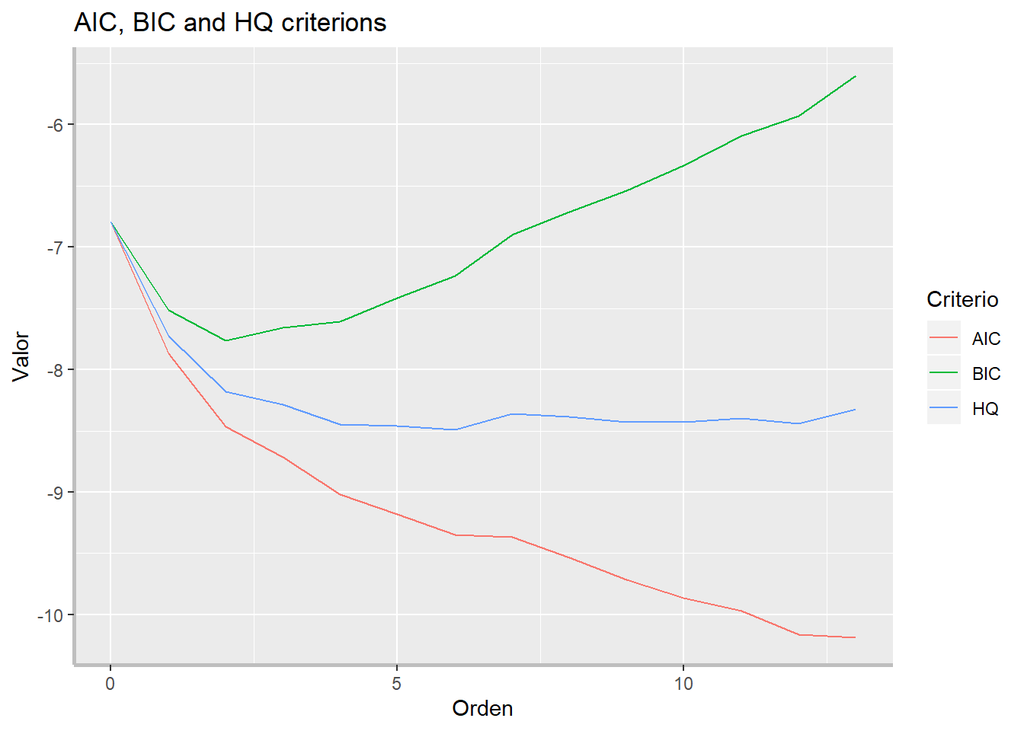

```r
criterios <- data.frame(cbind(round(0:13,0),var$aic,
                              var$bic,
                              var$hq))
names(criterios) <- c('p', 'AIC', 'BIC', 'HQ')

plot.crite <- data.frame(rbind(cbind(round(0:13,0), 'AIC', var$aic),
                               cbind(round(0:13,0), 'BIC', var$bic),
                               cbind(round(0:13,0), 'HQ', var$hq)))
names(plot.crite) <- c('p', 'Criterio', 'Valores')
plot.crite$p       <- as.numeric(as.character(plot.crite$p))
plot.crite$Valores <- as.numeric(as.character(plot.crite$Valores))

ggplot(plot.crite, aes(x = p,y = Valores, group = Criterio)) +
  geom_line(aes(color = Criterio)) +
  theme(axis.line = element_line(colour = "grey",
                      size = 1, linetype = "solid")) +
  ylab("Valor") +
  xlab("Orden") +
  ggtitle("AIC, BIC and HQ criterions")
```

```r
modelo <- VAR(multi, 1)
```

```
## Constant term:
## Estimates:  0.0001214053 -0.0006599502 -0.002896774 0.02159971
## Std.Error:  0.00337113 0.02078139 0.03410996 0.5308774
## AR coefficient matrix
## AR( 1 )-matrix
##        [,1]     [,2]     [,3]      [,4]
## [1,] -0.432 -0.00229 -0.00497  0.000414
## [2,] -0.151 -0.52980  0.04339 -0.000694
## [3,] -0.708 -0.19672 -0.43925 -0.005686
## [4,]  2.514  0.27365  3.16356 -0.558546
## standard error
##         [,1]   [,2]    [,3]     [,4]
## [1,]  0.0882 0.0137 0.00797 0.000485
## [2,]  0.5438 0.0842 0.04915 0.002987
## [3,]  0.8926 0.1382 0.08068 0.004903
## [4,] 13.8921 2.1508 1.25570 0.076302
##
## Residuals cov-mtx:
##             [,1]          [,2]          [,3]        [,4]
## [1,] 0.001409085  0.0029312443  0.0031408313  0.02892543
## [2,] 0.002931244  0.0535469995 -0.0008814765  0.42304006
## [3,] 0.003140831 -0.0008814765  0.1442608389  0.06920916
## [4,] 0.028925431  0.4230400583  0.0692091592 34.94416093
##
## det(SSE) =  0.0002870749
## AIC =  -7.909613
## BIC =  -7.556686
## HQ  =  -7.766207
```

```r
### Residuales
resid <- modelo$residuals
mq(resid,adj=18)
```

```
## Ljung-Box Statistics:
##         m       Q(m)     df    p-value
##  [1,]   1.0      23.6    -2.0        1
##  [2,]   2.0     100.5    14.0        1
##  [3,]   3.0     130.5    30.0        0
##  [4,]   4.0     150.3    46.0        0
##  [5,]   5.0     178.6    62.0        0
##  [6,]   6.0     205.2    78.0        0
##  [7,]   7.0     230.9    94.0        0
##  [8,]   8.0     267.8   110.0        0
##  [9,]   9.0     303.0   126.0        0
## [10,]  10.0     336.9   142.0        0
## [11,]  11.0     364.1   158.0        0
## [12,]  12.0     393.5   174.0        0
## [13,]  13.0     424.9   190.0        0
## [14,]  14.0     461.4   206.0        0
## [15,]  15.0     480.5   222.0        0
## [16,]  16.0     519.2   238.0        0
## [17,]  17.0     535.6   254.0        0
## [18,]  18.0     567.0   270.0        0
## [19,]  19.0     587.5   286.0        0
## [20,]  20.0     613.7   302.0        0
## [21,]  21.0     637.5   318.0        0
## [22,]  22.0     655.9   334.0        0
## [23,]  23.0     685.2   350.0        0
## [24,]  24.0     711.9   366.0        0
```

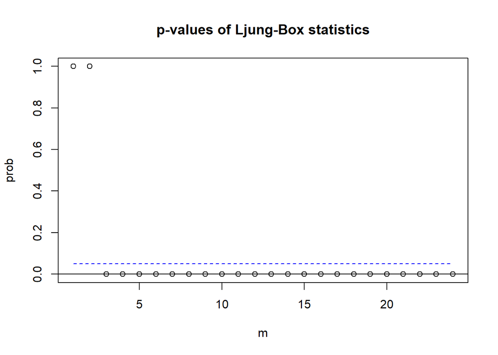

```r
modelo1 <- VAR(multi, 2)
```

```
## Constant term:
## Estimates:  -9.904991e-05 0.002923274 -0.004464725 0.06200216
## Std.Error:  0.0030268 0.01910485 0.03246442 0.5082141
## AR coefficient matrix
## AR( 1 )-matrix
##        [,1]     [,2]     [,3]      [,4]
## [1,] -0.649  0.00792  0.00465  0.001095
## [2,]  0.235 -0.70378  0.09368 -0.000541
## [3,] -1.741 -0.17154 -0.55944 -0.006595
## [4,]  7.550  1.82480  4.77709 -0.747881
## standard error
##         [,1]   [,2]   [,3]     [,4]
## [1,]  0.0879 0.0145 0.0082 0.000537
## [2,]  0.5546 0.0916 0.0518 0.003392
## [3,]  0.9424 0.1556 0.0880 0.005764
## [4,] 14.7523 2.4360 1.3776 0.090238
## AR( 2 )-matrix
##        [,1]    [,2]    [,3]     [,4]
## [1,] -0.469  0.0261  0.0162  0.00109
## [2,]  0.498 -0.3308  0.1792  0.00475
## [3,] -2.710  0.1098 -0.1884 -0.00828
## [4,] -1.775  3.3996  4.3509 -0.24337
## standard error
##         [,1]   [,2]    [,3]    [,4]
## [1,]  0.0876 0.0147 0.00813 0.00053
## [2,]  0.5528 0.0930 0.05132 0.00334
## [3,]  0.9394 0.1581 0.08721 0.00568
## [4,] 14.7058 2.4747 1.36529 0.08891
##
## Residuals cov-mtx:
##             [,1]        [,2]        [,3]        [,4]
## [1,] 0.001089829 0.002999428 0.002329585  0.03147511
## [2,] 0.002999428 0.043418836 0.007424357  0.36758168
## [3,] 0.002329585 0.007424357 0.125373603  0.15207951
## [4,] 0.031475106 0.367581681 0.152079509 30.72444858
##
## det(SSE) =  0.0001269489
## AIC =  -8.479418
## BIC =  -7.773563
## HQ  =  -8.192606
```

```r
### Residuales
resid1 <- modelo1$residuals
mq(resid1,adj=18)
```

```
## Ljung-Box Statistics:
##         m       Q(m)     df    p-value
##  [1,]   1.0       9.0    -2.0        1
##  [2,]   2.0      36.3    14.0        1
##  [3,]   3.0      71.4    30.0        0
##  [4,]   4.0      90.8    46.0        0
##  [5,]   5.0     114.7    62.0        0
##  [6,]   6.0     130.1    78.0        0
##  [7,]   7.0     144.6    94.0        0
##  [8,]   8.0     175.1   110.0        0
##  [9,]   9.0     207.2   126.0        0
## [10,]  10.0     232.3   142.0        0
## [11,]  11.0     249.6   158.0        0
## [12,]  12.0     278.5   174.0        0
## [13,]  13.0     308.9   190.0        0
## [14,]  14.0     327.5   206.0        0
## [15,]  15.0     347.8   222.0        0
## [16,]  16.0     375.4   238.0        0
## [17,]  17.0     385.5   254.0        0
## [18,]  18.0     415.8   270.0        0
## [19,]  19.0     430.0   286.0        0
## [20,]  20.0     450.6   302.0        0
## [21,]  21.0     465.6   318.0        0
## [22,]  22.0     482.5   334.0        0
## [23,]  23.0     502.0   350.0        0
## [24,]  24.0     522.2   366.0        0
```

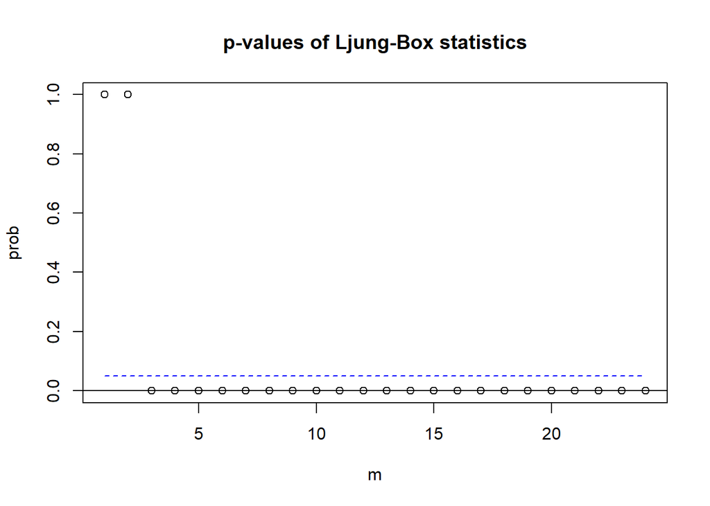

```r
modelo2 <- VAR(multi, 3)
```

```
## Constant term:
## Estimates:  1.262016e-05 0.003336607 0.0001176336 0.06652982
## Std.Error:  0.002909456 0.01869147 0.03010281 0.4883268
## AR coefficient matrix
## AR( 1 )-matrix
##        [,1]    [,2]     [,3]     [,4]
## [1,] -0.805  0.0126  0.00119  0.00114
## [2,] -0.183 -0.7545  0.11693 -0.00186
## [3,] -1.610 -0.1192 -0.70094 -0.00365
## [4,] -2.123  3.3680  4.55833 -0.86291
## standard error
##         [,1]   [,2]    [,3]     [,4]
## [1,]  0.0991 0.0161 0.00841 0.000553
## [2,]  0.6364 0.1033 0.05400 0.003550
## [3,]  1.0250 0.1663 0.08696 0.005717
## [4,] 16.6275 2.6975 1.41073 0.092736
## AR( 2 )-matrix
##         [,1]      [,2]    [,3]     [,4]
## [1,]  -0.674  2.41e-02  0.0169  0.00141
## [2,]   0.106 -3.93e-01  0.2591  0.00334
## [3,]  -3.261 -2.26e-05 -0.4462 -0.00796
## [4,] -12.901  6.05e+00  5.7003 -0.46504
## standard error
##        [,1]   [,2]    [,3]     [,4]
## [1,]  0.107 0.0186 0.00959 0.000672
## [2,]  0.685 0.1195 0.06162 0.004319
## [3,]  1.103 0.1924 0.09924 0.006956
## [4,] 17.888 3.1208 1.60982 0.112846
## AR( 3 )-matrix
##         [,1]     [,2]    [,3]     [,4]
## [1,]  -0.358  0.00247  0.0118  0.00028
## [2,]  -0.873 -0.04169  0.1657  0.00045
## [3,]  -1.779 -0.15090 -0.2586 -0.00718
## [4,] -31.478  4.74558  3.4604 -0.25323
## standard error
##         [,1]   [,2]    [,3]     [,4]
## [1,]  0.0992 0.0159 0.00856 0.000547
## [2,]  0.6373 0.1024 0.05498 0.003513
## [3,]  1.0264 0.1650 0.08855 0.005657
## [4,] 16.6501 2.6764 1.43639 0.091773
##
## Residuals cov-mtx:
##             [,1]        [,2]        [,3]        [,4]
## [1,] 0.000963964 0.002531995 0.001860548  0.02148496
## [2,] 0.002531995 0.039785445 0.010929312  0.29553572
## [3,] 0.001860548 0.010929312 0.103193230  0.17453424
## [4,] 0.021484962 0.295535725 0.174534235 27.15552275
##
## det(SSE) =  7.824543e-05
## AIC =  -8.717199
## BIC =  -7.658417
## HQ  =  -8.28698
```

```r
### Residuales
resid2 <- modelo2$residuals
mq(resid2,adj=18)
```

```
## Ljung-Box Statistics:
##          m       Q(m)     df    p-value
##  [1,]   1.00      8.54   -2.00     1.00
##  [2,]   2.00     26.86   14.00     1.00
##  [3,]   3.00     41.34   30.00     0.08
##  [4,]   4.00     65.82   46.00     0.03
##  [5,]   5.00     83.71   62.00     0.03
##  [6,]   6.00    100.57   78.00     0.04
##  [7,]   7.00    115.94   94.00     0.06
##  [8,]   8.00    148.27  110.00     0.01
##  [9,]   9.00    170.38  126.00     0.01
## [10,]  10.00    196.28  142.00     0.00
## [11,]  11.00    210.54  158.00     0.00
## [12,]  12.00    235.86  174.00     0.00
## [13,]  13.00    256.32  190.00     0.00
## [14,]  14.00    276.93  206.00     0.00
## [15,]  15.00    292.15  222.00     0.00
## [16,]  16.00    314.04  238.00     0.00
## [17,]  17.00    324.46  254.00     0.00
## [18,]  18.00    346.71  270.00     0.00
## [19,]  19.00    360.14  286.00     0.00
## [20,]  20.00    378.53  302.00     0.00
## [21,]  21.00    392.23  318.00     0.00
## [22,]  22.00    408.38  334.00     0.00
## [23,]  23.00    422.33  350.00     0.00
## [24,]  24.00    438.57  366.00     0.01
```

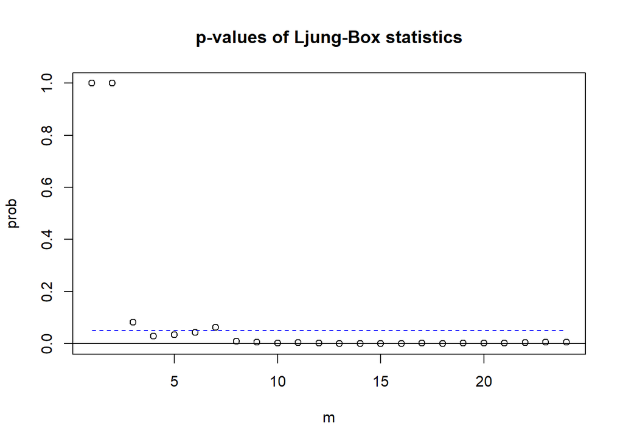

```r
modelo3 <- VAR(multi, 4)
```

```
## Constant term:
## Estimates:  0.0001109825 0.00273222 -0.000941415 0.03235332
## Std.Error:  0.002696296 0.0182407 0.02855849 0.466697
## AR coefficient matrix
## AR( 1 )-matrix
##         [,1]     [,2]     [,3]      [,4]
## [1,]  -0.922  0.00687  0.00687  0.000906
## [2,]  -0.704 -0.80095  0.14214 -0.002790
## [3,]  -2.159  0.02560 -0.84314 -0.005483
## [4,] -13.348  3.55462  4.59829 -0.973947
## standard error
##         [,1]   [,2]    [,3]     [,4]
## [1,]  0.0956 0.0153 0.00864 0.000538
## [2,]  0.6468 0.1035 0.05844 0.003639
## [3,]  1.0126 0.1620 0.09150 0.005698
## [4,] 16.5484 2.6478 1.49522 0.093116
## AR( 2 )-matrix
##         [,1]    [,2]    [,3]     [,4]
## [1,]  -0.956  0.0293  0.0238  0.00124
## [2,]  -0.935 -0.4359  0.2886  0.00305
## [3,]  -4.436  0.2878 -0.6674 -0.00898
## [4,] -38.657  9.3876  5.4237 -0.63724
## standard error
##        [,1]   [,2]   [,3]     [,4]
## [1,]  0.120 0.0197 0.0103 0.000698
## [2,]  0.812 0.1333 0.0699 0.004722
## [3,]  1.271 0.2087 0.1095 0.007394
## [4,] 20.776 3.4113 1.7888 0.120824
## AR( 3 )-matrix
##        [,1]    [,2]    [,3]     [,4]
## [1,]  -0.64  0.0133  0.0292  0.00075
## [2,]  -1.83 -0.1098  0.2410  0.00245
## [3,]  -3.72  0.0474 -0.5126 -0.01066
## [4,] -59.61  8.7318  4.5537 -0.44916
## standard error
##        [,1]   [,2]   [,3]    [,4]
## [1,]  0.119 0.0192 0.0108 0.00069
## [2,]  0.808 0.1300 0.0728 0.00467
## [3,]  1.265 0.2035 0.1139 0.00730
## [4,] 20.669 3.3249 1.8620 0.11938
```

[output cut: 9 more lines]

```
## [2,]  0.681 0.1022 0.05981 0.003564
## [3,]  1.066 0.1600 0.09364 0.005580
## [4,] 17.426 2.6154 1.53024 0.091182
##
## Residuals cov-mtx:
##              [,1]        [,2]        [,3]         [,4]
## [1,] 0.0007905747 0.001844852 0.001895359  0.008401055
## [2,] 0.0018448519 0.036181860 0.011430732  0.237970859
## [3,] 0.0018953595 0.011430732 0.088690772  0.065617892
## [4,] 0.0084010546 0.237970859 0.065617892 23.685244131
##
## det(SSE) =  4.600684e-05
## AIC =  -9.002105
## BIC =  -7.590396
## HQ  =  -8.42848
```

```r
### Residuales
resid3 <- modelo3$residuals
mq(resid3,adj=18)
```

```
## Ljung-Box Statistics:
##          m       Q(m)     df    p-value
##  [1,]   1.00      5.14   -2.00     1.00
##  [2,]   2.00     18.68   14.00     1.00
##  [3,]   3.00     29.07   30.00     0.51
##  [4,]   4.00     47.30   46.00     0.42
##  [5,]   5.00     62.95   62.00     0.44
##  [6,]   6.00     76.85   78.00     0.52
##  [7,]   7.00     99.30   94.00     0.33
##  [8,]   8.00    131.21  110.00     0.08
##  [9,]   9.00    145.31  126.00     0.11
## [10,]  10.00    174.76  142.00     0.03
## [11,]  11.00    188.64  158.00     0.05
## [12,]  12.00    216.65  174.00     0.02
## [13,]  13.00    234.06  190.00     0.02
## [14,]  14.00    250.31  206.00     0.02
## [15,]  15.00    269.26  222.00     0.02
## [16,]  16.00    285.80  238.00     0.02
## [17,]  17.00    294.99  254.00     0.04
## [18,]  18.00    310.30  270.00     0.05
## [19,]  19.00    321.36  286.00     0.07
## [20,]  20.00    336.48  302.00     0.08
## [21,]  21.00    353.36  318.00     0.08
## [22,]  22.00    369.69  334.00     0.09
## [23,]  23.00    382.45  350.00     0.11
## [24,]  24.00    395.61  366.00     0.14
```

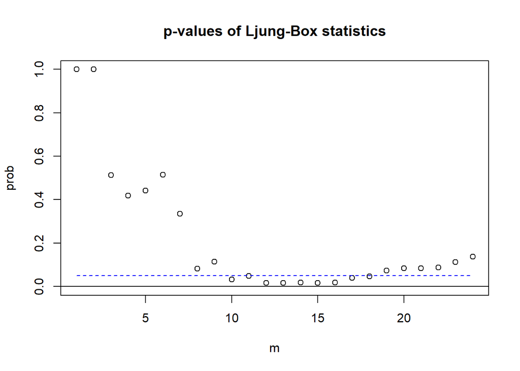

```r
### Simplificación del modelo
modelo3.2 <- refVAR(modelo3, thres=1.96) # Model refinement.
```

```
## Constant term:
## Estimates:  0 0 0 0
## Std.Error:  0 0 0 0
## AR coefficient matrix
## AR( 1 )-matrix
##        [,1]   [,2]   [,3]  [,4]
## [1,] -0.864  0.000  0.000  0.00
## [2,]  0.000 -0.828  0.132  0.00
## [3,] -2.441  0.000 -0.833  0.00
## [4,]  0.000  0.000  4.493 -0.91
## standard error
##        [,1]   [,2]   [,3]   [,4]
## [1,] 0.0839 0.0000 0.0000 0.0000
## [2,] 0.0000 0.0845 0.0549 0.0000
## [3,] 0.8735 0.0000 0.0874 0.0000
## [4,] 0.0000 0.0000 1.4349 0.0886
## AR( 2 )-matrix
##        [,1]   [,2]    [,3]   [,4]
## [1,] -0.812  0.000  0.0255  0.000
## [2,]  0.000 -0.380  0.2724  0.000
## [3,] -4.915  0.238 -0.6571  0.000
## [4,]  0.000  0.000  5.2509 -0.545
## standard error
##       [,1]   [,2]    [,3]  [,4]
## [1,] 0.101 0.0000 0.00764 0.000
## [2,] 0.000 0.0853 0.06557 0.000
## [3,] 1.073 0.1135 0.09886 0.000
## [4,] 0.000 0.0000 1.76252 0.111
## AR( 3 )-matrix
##         [,1] [,2]    [,3]   [,4]
## [1,]  -0.549    0  0.0333  0.000
## [2,]  -1.249    0  0.2246  0.000
## [3,]  -4.130    0 -0.5268  0.000
## [4,] -27.355    0  4.6946 -0.399
## standard error
##        [,1] [,2]    [,3]  [,4]
## [1,]  0.100    0 0.00855 0.000
## [2,]  0.525    0 0.06523 0.000
## [3,]  1.057    0 0.09806 0.000
## [4,] 13.578    0 1.74299 0.107
```

[output cut: 9 more lines]

```
## [2,]  0.5257    0 0.05436 0.0000
## [3,]  0.9378    0 0.08553 0.0000
## [4,] 13.8072    0 1.47014 0.0843
##
## Residuals cov-mtx:
##              [,1]        [,2]        [,3]        [,4]
## [1,] 0.0008913833 0.001895302 0.001678325  0.01444465
## [2,] 0.0018953020 0.038435663 0.011024975  0.22836057
## [3,] 0.0016783252 0.011024975 0.092057668  0.07694022
## [4,] 0.0144446505 0.228360571 0.076940221 25.74594443
##
## det(SSE) =  6.524994e-05
## AIC =  -9.114209
## BIC =  -8.364238
## HQ  =  -8.80947
```

```r
#MTSdiag(modelo3.2, adj=12)
resid3.2 <- modelo3.2$residuals
mq(resid3.2, adj=18)
```

```
## Ljung-Box Statistics:
##         m       Q(m)     df    p-value
##  [1,]   1.0      19.0    -2.0     1.00
##  [2,]   2.0      45.0    14.0     1.00
##  [3,]   3.0      55.1    30.0     0.00
##  [4,]   4.0      73.0    46.0     0.01
##  [5,]   5.0      89.3    62.0     0.01
##  [6,]   6.0     104.0    78.0     0.03
##  [7,]   7.0     119.2    94.0     0.04
##  [8,]   8.0     151.2   110.0     0.01
##  [9,]   9.0     166.9   126.0     0.01
## [10,]  10.0     194.3   142.0     0.00
## [11,]  11.0     206.8   158.0     0.01
## [12,]  12.0     227.0   174.0     0.00
## [13,]  13.0     248.5   190.0     0.00
## [14,]  14.0     270.3   206.0     0.00
## [15,]  15.0     292.4   222.0     0.00
## [16,]  16.0     311.5   238.0     0.00
## [17,]  17.0     318.9   254.0     0.00
## [18,]  18.0     337.0   270.0     0.00
## [19,]  19.0     345.9   286.0     0.01
## [20,]  20.0     362.2   302.0     0.01
## [21,]  21.0     382.6   318.0     0.01
## [22,]  22.0     392.9   334.0     0.01
## [23,]  23.0     405.9   350.0     0.02
## [24,]  24.0     416.1   366.0     0.04
```

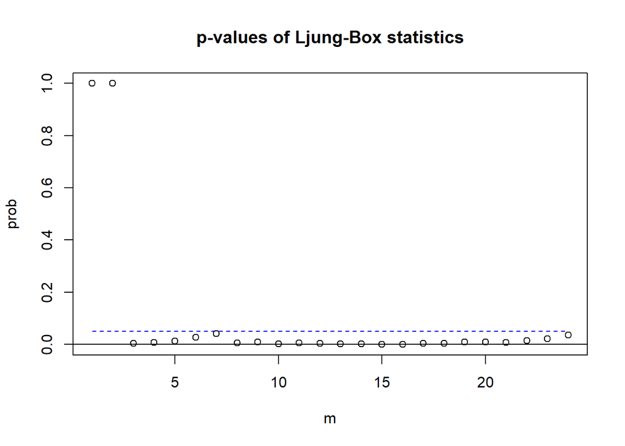

```r
modelo4 <- VAR(multi, 5)
```

```
## Constant term:
## Estimates:  0.0001863647 0.001926642 -0.0001742604 -0.009404499
## Std.Error:  0.002714676 0.01780688 0.0269912 0.4528856
## AR coefficient matrix
## AR( 1 )-matrix
##        [,1]     [,2]     [,3]      [,4]
## [1,]  -1.00  0.00445  0.00815  0.000757
## [2,]  -1.08 -0.86275  0.14759 -0.003372
## [3,]  -2.19  0.07296 -0.93417 -0.002898
## [4,] -10.71  3.52694  3.40867 -1.065253
## standard error
##        [,1]   [,2]    [,3]     [,4]
## [1,]  0.104 0.0158 0.00947 0.000574
## [2,]  0.683 0.1034 0.06213 0.003768
## [3,]  1.036 0.1567 0.09418 0.005711
## [4,] 17.378 2.6298 1.58027 0.095829
## AR( 2 )-matrix
##        [,1]   [,2]    [,3]     [,4]
## [1,]  -1.08  0.028  0.0266  0.00110
## [2,]  -1.80 -0.495  0.2923  0.00270
## [3,]  -5.01  0.430 -0.8636 -0.00268
## [4,] -45.64 10.091  4.1242 -0.80049
## standard error
##        [,1]   [,2]   [,3]    [,4]
## [1,]  0.135 0.0206 0.0124 0.00078
## [2,]  0.886 0.1354 0.0811 0.00511
## [3,]  1.343 0.2053 0.1230 0.00775
## [4,] 22.542 3.4447 2.0634 0.13007
## AR( 3 )-matrix
##         [,1]    [,2]    [,3]      [,4]
## [1,]  -0.825  0.0176  0.0337  0.000769
## [2,]  -2.910 -0.1849  0.2541  0.004463
## [3,]  -5.129  0.2221 -0.7509 -0.000834
## [4,] -71.804 11.0302  3.0408 -0.615991
## standard error
##        [,1]   [,2]   [,3]    [,4]
## [1,]  0.156 0.0228 0.0135 0.00081
## [2,]  1.025 0.1494 0.0887 0.00532
## [3,]  1.554 0.2265 0.1345 0.00806
## [4,] 26.068 3.8002 2.2564 0.13521
```

[output cut: 21 more lines]

```
## [2,]  0.738 0.1035 0.06444 0.003706
## [3,]  1.118 0.1569 0.09767 0.005617
## [4,] 18.762 2.6330 1.63879 0.094253
##
## Residuals cov-mtx:
##              [,1]        [,2]        [,3]         [,4]
## [1,] 0.0007641358 0.001643936 0.001788484  0.007475868
## [2,] 0.0016439362 0.032878364 0.011309807  0.197420896
## [3,] 0.0017884838 0.011309807 0.075540359  0.116869566
## [4,] 0.0074758684 0.197420896 0.116869566 21.267261969
##
## det(SSE) =  3.119649e-05
## AIC =  -9.144436
## BIC =  -7.379799
## HQ  =  -8.427405
```

```r
### Residuales
resid4 <- modelo4$residuals
mq(resid4,adj=18)
```

```
## Ljung-Box Statistics:
##          m       Q(m)     df    p-value
##  [1,]   1.00      6.65   -2.00     1.00
##  [2,]   2.00     12.43   14.00     1.00
##  [3,]   3.00     20.83   30.00     0.89
##  [4,]   4.00     31.73   46.00     0.95
##  [5,]   5.00     40.34   62.00     0.99
##  [6,]   6.00     47.84   78.00     1.00
##  [7,]   7.00     73.40   94.00     0.94
##  [8,]   8.00    102.99  110.00     0.67
##  [9,]   9.00    116.48  126.00     0.72
## [10,]  10.00    139.12  142.00     0.55
## [11,]  11.00    156.33  158.00     0.52
## [12,]  12.00    186.78  174.00     0.24
## [13,]  13.00    201.64  190.00     0.27
## [14,]  14.00    215.67  206.00     0.31
## [15,]  15.00    231.68  222.00     0.31
## [16,]  16.00    245.94  238.00     0.35
## [17,]  17.00    258.29  254.00     0.41
## [18,]  18.00    270.92  270.00     0.47
## [19,]  19.00    284.66  286.00     0.51
## [20,]  20.00    297.11  302.00     0.57
## [21,]  21.00    314.67  318.00     0.54
## [22,]  22.00    329.37  334.00     0.56
## [23,]  23.00    343.18  350.00     0.59
## [24,]  24.00    356.73  366.00     0.63
```

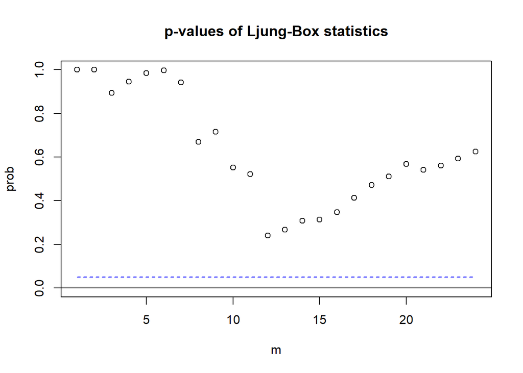

```r
### Pronóstico
#VARpred(modelo.2, 8)
```